# MatPlotlib - Simplilearn

## Matplotlib

This is a 2D plotting library

Other python data visualization libraries

- pygal
- folium
- networkx
- vispy
- bokeh
- seaborn

#### Steps to create a plot

1. Import the libraries
2. Define or import the required dataset
3. Set the plot parameters
4. Display the created plot

```python
# import numpy for generating random numbers
import numpy as np

# import matplotlib library
import matplotlib.pyplot as plt
from matplotlib import style
%matplotlib inline
```

```python
# generate random numbers (total 10)
randomNumber = np.random.rand(10)
```

```python
# view them
print(randomNumber)
```

```
[0.3171416  0.26569313 0.0052598  0.36189973 0.79272216 0.15056516
 0.52970655 0.66117205 0.75326969 0.05946637]
```

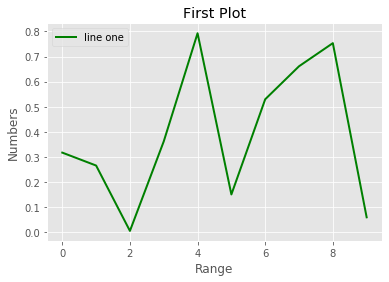

```python
# select the style of the plot
style.use('ggplot')

# plot the random number
plt.plot(randomNumber, 'g', label='line one', linewidth=2)

# x axis is number of random numbers(index)
plt.xlabel('Range')

# y axis is actual random number
plt.ylabel('Numbers')

# Title of the plot
plt.title('First Plot')

plt.legend()
plt.show()
```

### Line Properties

- alpha = float
- animated = True or False
- antialiased or aa = True or False
- linestyle or ls = '-', '--', '-.',':','steps',
- linewidth or lw = float
- marker = '+', ',', '.', '1', '2', '3', '4'
- color or c = b, r, c for cyan, m for magneta, g, y, k for black, w for white

A Nutri-wide firm wants to know how many people visits its website in a particular time. This analysis helps it control and monitor the website traffic.

```python
import matplotlib.pyplot as plt
from matplotlib import style
%matplotlib inline
```

```python
# website traffic data
# number of users/visitors on the web site
web_customers = [123, 645, 950, 1290, 1630, 1450, 1034, 1295, 465, 205, 80]

# time distribution (hourly)
time_hrs = [7, 8, 9, 10, 11, 12, 13, 14, 15, 16, 17]
```

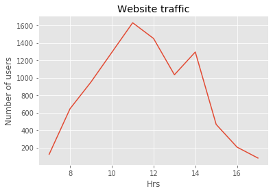

```python
# select the style of the plot
style.use('ggplot')

# plot the website traffic data (X-axis hrs and y axis as number of users)
plt.plot(time_hrs, web_customers)

# set the title of the plot
plt.title('Website traffic')

# set label for x axis
plt.xlabel('Hrs')

# set label for y axis
plt.ylabel('Number of users')
plt.show()
```

### To change the linestyle

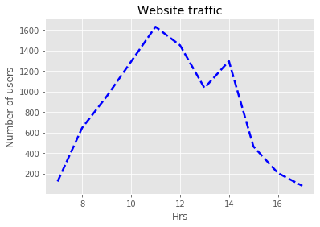

```python
# select the style of the plot
style.use('ggplot')

# plot the website traffic data (X-axis hrs and y axis as number of users)
plt.plot(time_hrs, web_customers, color='b', linestyle='--', linewidth=2.5 )

# set the title of the plot
plt.title('Website traffic')

# set label for x axis
plt.xlabel('Hrs')

# set label for y axis
plt.ylabel('Number of users')
plt.show()
```

### To set the axis, Labels and Legend property

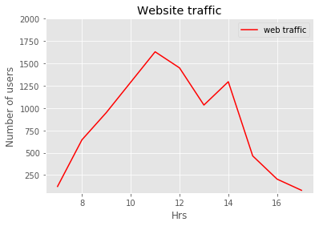

```python
# select the style of the plot
style.use('ggplot')

# plot the website traffic data (x-axis hrs and y axis as number of users)
plt.plot(time_hrs, web_customers, 'r', label='web traffic', linewidth=1.5)
plt.axis([6.5, 17.5, 50, 2000])

# set the title of the plot
plt.title('Website traffic')

# set label for x-axis
plt.xlabel ('Hrs')

# set label for y axis
plt.ylabel('Number of users')
plt.legend()
plt.show()
```

### Alpha (transparency) and Annotation

The lower the alpha value, the more transparent the line

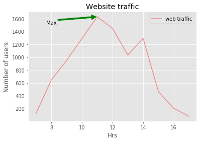

```python
# select the style of the plot
style.use('ggplot')

# plot the website traffic data (x-axis hrs and y axis as number of users)
plt.plot(time_hrs, web_customers, 'r', label='web traffic', linewidth=1.5, alpha=0.4)

# set the title of the plot
plt.title('Website traffic')

# annotate
plt.annotate('Max', ha='center', va='bottom', xytext=(8, 1500), xy=(11,1630), arrowprops={'facecolor':'green'})

# set label for x-axis
plt.xlabel ('Hrs')

# set label for y axis
plt.ylabel('Number of users')
plt.legend()
plt.show()
```

where:

```
'Max' indicates the annotation text
'ha' indicates the horizontal alignment
'va' indicates the vertical alignment
'xytext' indicates the text position
'xy' indicates the arrow position
'arrowprops' indicates the properties of the arrow
```

## How to create Multiple plots

```python
# website traffic data
# number of users/visitors on the website
web_monday = [123, 645, 950, 1290, 1630, 1450, 1034, 1295, 465, 205, 80]

# Tuesday web traffic
web_tuesday = [95, 680, 889, 1145, 1670, 1323, 1119, 1265, 510, 310, 110]

# wednesday web traffic
web_wednesday = [105, 630, 700, 1006, 1520, 1124, 1239, 1380, 580, 610, 230]

# time distrubtion (hourly)
time_hrs = [7, 8, 9, 10, 11, 12, 13, 14, 15, 16, 17]
```

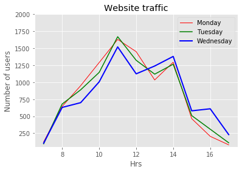

```python
# select the style of the plot
style.use('ggplot')

# plot the website traffic data (X-axis hrs and y-axis as number of users)
# plot the monday web traffic with red color
plt.plot(time_hrs, web_monday, 'r', label='Monday', linewidth=1)
# plot the tuesday web traffic with green color
plt.plot(time_hrs, web_tuesday, 'g', label='Tuesday', linewidth=1.5)
# plot the wednesday web traffic with blue color
plt.plot(time_hrs, web_wednesday, 'b', label='Wednesday', linewidth=2)
plt.axis([6.5, 17.5, 50, 2000])

# set the title of the plot
plt.title('Website traffic')

# set label for x axis
plt.xlabel('Hrs')

# set label for y axis
plt.ylabel('Number of users')

plt.legend()
plt.show()
```

## How to create subplots

A subplot is used to display multiple plots in the same window. With subplot, you can arrange plots in a regular grid. All you need to do is specify the rows, columns, and plot.

The syntax for subplot is subplot(m, n, p). It divides the current window into m-by-n grid and creates an axis for a subplot in the position specified by p. i.e subplot(2,1,1) and subplot(2,1,2) indicates 2 vertically stacked plots 1 and 2.

### Layout and Spacing Adjustments

Layout and spacing adjustments are 2 important factors to be considered while creating subplots.

Use plt.subplots_adjust() method with the parameters hspace (top) and wspace (bottom) to adjust the distances between the subplot and move them around on the grid.

```python
# import required libraries
import matplotlib.pyplot as plt
from matplotlib import style
%matplotlib inline
# to view the data inside jupyter notebook
```

```python
# define the temp, wind, humidity, precipitation data and Time hrs data
temp = [79, 75, 74, 73, 81, 77, 81, 95, 93, 95, 97, 98, 99, 98, 98, 97, 92, 94, 92, 83, 83, 83, 82, 81]
wind = [14, 12, 10, 13, 9, 13, 12, 13, 17, 13, 17, 18, 7, 25, 10, 16, 0, 16, 0, 16, 9, 9, 9, 5]
time_hrs = [1, 2, 3, 4, 5, 6, 7, 8, 9, 10, 11, 12, 13, 14, 15, 16, 17, 18, 19, 20, 21, 22, 23, 24]
humidity = [73, 76, 78, 81, 81, 84, 84, 79, 71, 64, 58, 55, 51, 48, 46, 46, 45, 46, 48, 53, 60, 67, 69, 73]
precipitation = [26, 42, 69, 48, 11, 16, 5, 11, 3, 48, 26, 21, 58, 69, 74, 53, 79, 53, 58, 26, 74, 95, 69, 58]
```

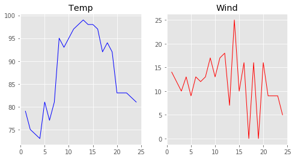

```python
# draw subplots for (1, 2, 1) and (1, 2, 2) i.e. display side-by-side
plt.figure(figsize = (8, 4))
plt.subplots_adjust(hspace=0.25)
plt.subplot(1, 2, 1)
plt.title('Temp')
plt.plot(time_hrs, temp, color='b', linestyle='-', linewidth=1)
plt.subplot(1, 2, 2)
plt.title('Wind')
plt.plot(time_hrs, wind, color='r', linestyle='-', linewidth=1)
```

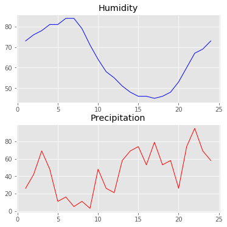

```python
# draw subplots for (2, 1, 1) and (2, 1, 2)
plt.figure(figsize = (6, 6))
plt.subplots_adjust(hspace=0.25)
plt.subplot(2, 1, 1)
plt.title('Humidity')
plt.plot(time_hrs, humidity, color='b', linestyle='-', linewidth=1)
plt.subplot(2, 1, 2)
plt.title('Precipitation')
plt.plot(time_hrs, precipitation, color='r', linestyle='-', linewidth=1)
```

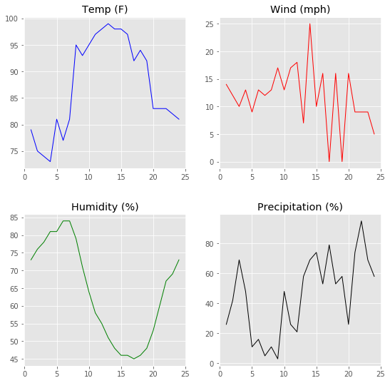

```python
# draw subplots for (2, 2, 1), (2, 2, 2), (2, 2, 3) and (2, 2, 4)
plt.figure(figsize = (9, 9))
plt.subplots_adjust(hspace=0.3)
plt.subplot(2, 2, 1)
plt.title('Temp (F)')
plt.plot(time_hrs, temp, color='b', linestyle='-', linewidth=1)
plt.subplot(2, 2, 2)
plt.title('Wind (mph)')
plt.plot(time_hrs, wind, color='r', linestyle='-', linewidth=1)
plt.subplot(2, 2, 3)
plt.title('Humidity (%)')
plt.plot(time_hrs, humidity, color='g', linestyle='-', linewidth=1)
plt.subplot(2, 2, 4)
plt.title('Precipitation (%)')
plt.plot(time_hrs, precipitation, color='k', linestyle='-', linewidth=1)
```

## Types of Plot

You can create different types of plots using matplotlib:

- Histogram - create using the matplotlib and its bar chart fxn
- Scatterplot - create using scatter() method
- Pie chart -
- Heatmap
- Error bar

### Histogram and scatterplot

```python
# import boston dataset from sklearn library

from sklearn.datasets import load_boston

# import matplotlib
import matplotlib.pyplot as plt
from matplotlib import style
%matplotlib inline
```

```python
# load boston dataset
boston_real_estate = load_boston()
```

```python
# view boston dataset
print(boston_real_estate.DESCR)
```

```
.. _boston_dataset:

Boston house prices dataset
---------------------------

**Data Set Characteristics:**

    :Number of Instances: 506

    :Number of Attributes: 13 numeric/categorical predictive. Median Value (attribute 14) is usually the target.

    :Attribute Information (in order):
        - CRIM     per capita crime rate by town
        - ZN       proportion of residential land zoned for lots over 25,000 sq.ft.
        - INDUS    proportion of non-retail business acres per town
        - CHAS     Charles River dummy variable (= 1 if tract bounds river; 0 otherwise)
        - NOX      nitric oxides concentration (parts per 10 million)
        - RM       average number of rooms per dwelling
        - AGE      proportion of owner-occupied units built prior to 1940
        - DIS      weighted distances to five Boston employment centres
        - RAD      index of accessibility to radial highways
        - TAX      full-value property-tax rate per $10,000
        - PTRATIO  pupil-teacher ratio by town
        - B        1000(Bk - 0.63)^2 where Bk is the proportion of blacks by town
        - LSTAT    % lower status of the population
        - MEDV     Median value of owner-occupied homes in $1000's

    :Missing Attribute Values: None

    :Creator: Harrison, D. and Rubinfeld, D.L.

This is a copy of UCI ML housing dataset.
https://archive.ics.uci.edu/ml/machine-learning-databases/housing/


This dataset was taken from the StatLib library which is maintained at Carnegie Mellon University.

The Boston house-price data of Harrison, D. and Rubinfeld, D.L. 'Hedonic
prices and the demand for clean air', J. Environ. Economics & Management,
vol.5, 81-102, 1978.   Used in Belsley, Kuh & Welsch, 'Regression diagnostics
...', Wiley, 1980.   N.B. Various transformations are used in the table on
pages 244-261 of the latter.

The Boston house-price data has been used in many machine learning papers that address regression
problems.

.. topic:: References

   - Belsley, Kuh & Welsch, 'Regression diagnostics: Identifying Influential Data and Sources of Collinearity', Wiley, 1980. 244-261.
   - Quinlan,R. (1993). Combining Instance-Based and Model-Based Learning. In Proceedings on the Tenth International Conference of Machine Learning, 236-243, University of Massachusetts, Amherst. Morgan Kaufmann.
```

```python
# define x axis for the data
x_axis = boston_real_estate.data
```

```python
# define y axis for the target
y_axis = boston_real_estate.target
```

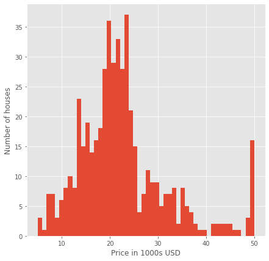

```python
# plot histogram
style.use('ggplot')
plt.figure(figsize=(7,7))
plt.hist(y_axis, bins=50)
plt.xlabel('Price in 1000s USD')
plt.ylabel('Number of houses')
plt.show()
```

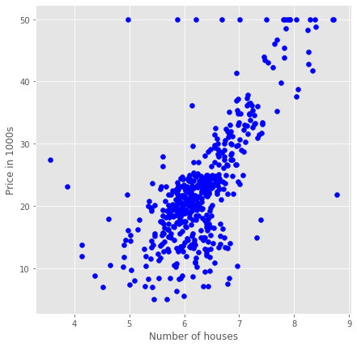

```python
# plot scatter plot
style.use('ggplot')
plt.figure(figsize=(7,7))
plt.scatter(boston_real_estate.data[:,5], boston_real_estate.target, color='b')
plt.ylabel('Price in 1000s')
plt.xlabel('Number of houses')
plt.show()
```

### Heat Map

```python
# import matplotlib
import matplotlib.pyplot as plt
# import seaborn library
import seaborn as sns
```

```python
# to show plot in notebook
%matplotlib inline
```

```python
# load flight data from sns dataseet (built in)
flight_data = sns.load_dataset('flights')
```

```python
# view top 5 records
flight_data.head()
```

|  | year | month | passengers |
| --- | --- | --- | --- |
| 0 | 1949 | January | 112 |
| 1 | 1949 | February | 118 |
| 2 | 1949 | March | 132 |
| 3 | 1949 | April | 129 |
| 4 | 1949 | May | 121 |

```python
# use pivot method to re-arrange the dataeset
flight_data = flight_data.pivot('month', 'year', 'passengers')
```

```python
# view the dataset
flight_data
```

| year month | 1949 | 1950 | 1951 | 1952 | 1953 | 1954 | 1955 | 1956 | 1957 | 1958 | 1959 | 1960 |
| --- | --- | --- | --- | --- | --- | --- | --- | --- | --- | --- | --- | --- |
| January | 112 | 115 | 145 | 171 | 196 | 204 | 242 | 284 | 315 | 340 | 360 | 417 |
| February | 118 | 126 | 150 | 180 | 196 | 188 | 233 | 277 | 301 | 318 | 342 | 391 |
| March | 132 | 141 | 178 | 193 | 236 | 235 | 267 | 317 | 356 | 362 | 406 | 419 |
| April | 129 | 135 | 163 | 181 | 235 | 227 | 269 | 313 | 348 | 348 | 396 | 461 |
| May | 121 | 125 | 172 | 183 | 229 | 234 | 270 | 318 | 355 | 363 | 420 | 472 |
| June | 135 | 149 | 178 | 218 | 243 | 264 | 315 | 374 | 422 | 435 | 472 | 535 |
| July | 148 | 170 | 199 | 230 | 264 | 302 | 364 | 413 | 465 | 491 | 548 | 622 |
| August | 148 | 170 | 199 | 242 | 272 | 293 | 347 | 405 | 467 | 505 | 559 | 606 |
| September | 136 | 158 | 184 | 209 | 237 | 259 | 312 | 355 | 404 | 404 | 463 | 508 |
| October | 119 | 133 | 162 | 191 | 211 | 229 | 274 | 306 | 347 | 359 | 407 | 461 |
| November | 104 | 114 | 146 | 172 | 180 | 203 | 237 | 271 | 305 | 310 | 362 | 390 |
| December | 118 | 140 | 166 | 194 | 201 | 229 | 278 | 306 | 336 | 337 | 405 | 432 |

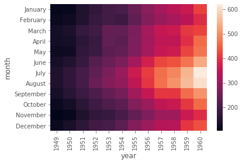

```python
# use the heatmap method to generate the heatmap of flight data by passing the flight data
sns.heatmap(flight_data)
```

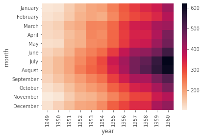

```python
# The default cmap is sns.cm.rocket. To reverse it set cmap to sns.cm.rocket_r
cmap = sns.cm.rocket_r
sns.heatmap(flight_data, cmap=cmap)
```

### Pie Chart

Is used to show percentage or proportional data

```python
# import required libraries
import matplotlib.pyplot as plt
%matplotlib inline
```

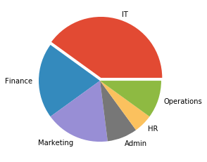

```python
# job data in percentile
job_data = ['40', '20', '17', '8', '5', '10']

# define label as different departments
labels = 'IT', 'Finance', 'Marketing', 'Admin', 'HR', 'Operations'

# explode the 1st slice which is IT
explode = (0.05, 0, 0, 0, 0, 0)

# draw the pie chart and set the parameters
plt.pie(job_data, labels=labels, explode=explode)
# show the plot
plt.show()
```

### Error Bars

Is used to graphically represent the variability of data and is used mainly to identify errors. It builds confidence about the data analysis by revealing the statistical difference between the two gropus of data.

### Seaborn

Developed in Stanford University

#### Draw a pair plot using seaborn library

DESCRIPTION

Problem:

Analyze the “auto mpg data” and draw a pair plot using seaborn library for mpg, weight, and origin.

Sources:

(a) Origin: This dataset was taken from the StatLib library maintained at Carnegie Mellon University.

```
Number of Instances: 398
Number of Attributes: 9 including the class attribute
Attribute Information:
mpg: continuous
cylinders: multi-valued discrete
displacement: continuous
horsepower: continuous
weight: continuous
acceleration: continuous
model year: multi-valued discrete
origin: multi-valued discrete
car name: string (unique for each instance)
```

```python
# import the required libraries
import pandas as pd
import matplotlib.pyplot as plt
import seaborn as sns
```

```python
# to view the plot in notebook
%matplotlib inline
```

```python
# import the auto dataset
auto = pd.read_csv('auto_data.csv')
```

```python
# view the top 5 records
auto.head()
```

|  | mpg | cylinders | displacement | horsepower | weight | acceleration | model_year | origin | name |
| --- | --- | --- | --- | --- | --- | --- | --- | --- | --- |
| 0 | 18.0 | 8 | 307.0 | 130 | 3504 | 12.0 | 70 | 1 | chevrolet chevelle malibu |
| 1 | 15.0 | 8 | 350.0 | 165 | 3693 | 11.5 | 70 | 1 | buick skylark 320 |
| 2 | 18.0 | 8 | 318.0 | 150 | 3436 | 11.0 | 70 | 1 | plymouth satellite |
| 3 | 16.0 | 8 | 304.0 | 150 | 3433 | 12.0 | 70 | 1 | amc rebel sst |
| 4 | 17.0 | 8 | 302.0 | 140 | 3449 | 10.5 | 70 | 1 | ford torino |

```python
# write a user defined function for origin
# 1-USA, 2-Europe, 3-Asia
def origin(num):
    if num==1:
        return 'USA'
    elif num==2:
        return 'Europe'
    elif num==3:
        return 'Asia'

# use apply function
auto['origin'] = auto['origin'].apply(origin)
```

```python
# view first 30 data poitns after appying the user defined function to dataset
auto.head(30)
```

|  | mpg | cylinders | displacement | horsepower | weight | acceleration | model_year | origin | name |
| --- | --- | --- | --- | --- | --- | --- | --- | --- | --- |
| 0 | 18.0 | 8 | 307.0 | 130 | 3504 | 12.0 | 70 | USA | chevrolet chevelle malibu |
| 1 | 15.0 | 8 | 350.0 | 165 | 3693 | 11.5 | 70 | USA | buick skylark 320 |
| 2 | 18.0 | 8 | 318.0 | 150 | 3436 | 11.0 | 70 | USA | plymouth satellite |
| 3 | 16.0 | 8 | 304.0 | 150 | 3433 | 12.0 | 70 | USA | amc rebel sst |
| 4 | 17.0 | 8 | 302.0 | 140 | 3449 | 10.5 | 70 | USA | ford torino |
| 5 | 15.0 | 8 | 429.0 | 198 | 4341 | 10.0 | 70 | USA | ford galaxie 500 |
| 6 | 14.0 | 8 | 454.0 | 220 | 4354 | 9.0 | 70 | USA | chevrolet impala |
| 7 | 14.0 | 8 | 440.0 | 215 | 4312 | 8.5 | 70 | USA | plymouth fury iii |
| 8 | 14.0 | 8 | 455.0 | 225 | 4425 | 10.0 | 70 | USA | pontiac catalina |
| 9 | 15.0 | 8 | 390.0 | 190 | 3850 | 8.5 | 70 | USA | amc ambassador dpl |
| 10 | 15.0 | 8 | 383.0 | 170 | 3563 | 10.0 | 70 | USA | dodge challenger se |
| 11 | 14.0 | 8 | 340.0 | 160 | 3609 | 8.0 | 70 | USA | plymouth 'cuda 340 |
| 12 | 15.0 | 8 | 400.0 | 150 | 3761 | 9.5 | 70 | USA | chevrolet monte carlo |
| 13 | 14.0 | 8 | 455.0 | 225 | 3086 | 10.0 | 70 | USA | buick estate wagon (sw) |
| 14 | 24.0 | 4 | 113.0 | 95 | 2372 | 15.0 | 70 | Asia | toyota corona mark ii |
| 15 | 22.0 | 6 | 198.0 | 95 | 2833 | 15.5 | 70 | USA | plymouth duster |
| 16 | 18.0 | 6 | 199.0 | 97 | 2774 | 15.5 | 70 | USA | amc hornet |
| 17 | 21.0 | 6 | 200.0 | 85 | 2587 | 16.0 | 70 | USA | ford maverick |
| 18 | 27.0 | 4 | 97.0 | 88 | 2130 | 14.5 | 70 | Asia | datsun pl510 |
| 19 | 26.0 | 4 | 97.0 | 46 | 1835 | 20.5 | 70 | Europe | volkswagen 1131 deluxe sedan |
| 20 | 25.0 | 4 | 110.0 | 87 | 2672 | 17.5 | 70 | Europe | peugeot 504 |
| 21 | 24.0 | 4 | 107.0 | 90 | 2430 | 14.5 | 70 | Europe | audi 100 ls |
| 22 | 25.0 | 4 | 104.0 | 95 | 2375 | 17.5 | 70 | Europe | saab 99e |
| 23 | 26.0 | 4 | 121.0 | 113 | 2234 | 12.5 | 70 | Europe | bmw 2002 |
| 24 | 21.0 | 6 | 199.0 | 90 | 2648 | 15.0 | 70 | USA | amc gremlin |
| 25 | 10.0 | 8 | 360.0 | 215 | 4615 | 14.0 | 70 | USA | ford f250 |
| 26 | 10.0 | 8 | 307.0 | 200 | 4376 | 15.0 | 70 | USA | chevy c20 |
| 27 | 11.0 | 8 | 318.0 | 210 | 4382 | 13.5 | 70 | USA | dodge d200 |
| 28 | 9.0 | 8 | 304.0 | 193 | 4732 | 18.5 | 70 | USA | hi 1200d |
| 29 | 27.0 | 4 | 97.0 | 88 | 2130 | 14.5 | 71 | Asia | datsun pl510 |

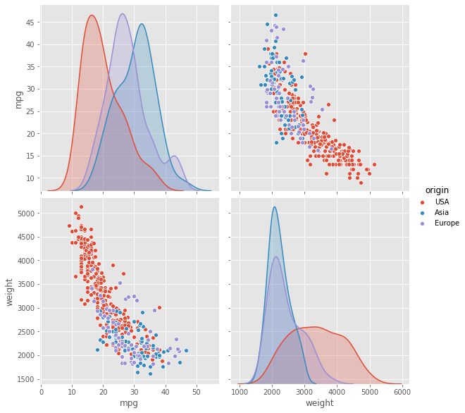

```python
# draw the pair plot using sns for mpg, weight, origin, and with hue origins, set the size to 4
# note: hue is variable in dataset to map plot aspects to different colors

sns.pairplot(auto[['mpg', 'weight', 'origin']], hue='origin', height=4)
```

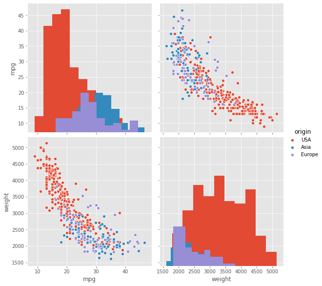

```python
sns.pairplot(auto[['mpg', 'weight', 'origin']], hue='origin', height=4, diag_kind="hist")
```

### Analysing Cause of Death

DESCRIPTION

What to:

You have been provided with a dataset that lists Ohio State’s leading causes of death from the year 2012.

Using the two data points:

```
Cause of deaths and
Percentile
Draw a pie chart to visualize the dataset
```

```python
# import required libraries
import matplotlib.pyplot as plt
%matplotlib inline
```

```python
# data from Ohio state,leading cause of death in the state from year 2012
# causes of death
cause ='Chronic Diseases', 'Unintentional Injuries', 'Alzheimers', 'Influenza and Pneumonia', 'Sepsis', 'Others'

# percentile
percentile = [62, 5, 4, 2, 1, 26]
```

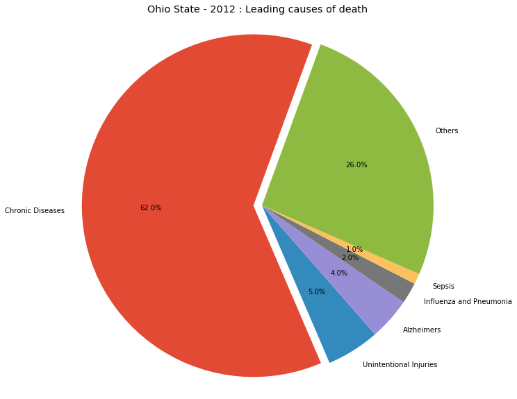

```python
# set the pie chart plot properties
# set figure size
plt.figure(figsize=(10, 10))

# explode the largest pie in the dataset
explode=(0.05, 0, 0, 0, 0, 0)
# set pie chart properties
plt.pie(percentile, labels=cause, explode=explode, autopct='%1.1f%%', startangle=70)
# set axis equal to draw pie as circle
plt.axis('equal')
# set title of the pie chart
plt.title('Ohio State - 2012 : Leading causes of death')
# show the plot (pie chart)
plt.show()
```

To display the plot on Jupyter notebook 'import'%matplotlib inline.'

Alpha decides the line transparency in line properties while plotting line plot/ chart.

Heat Map is used to represent data in two dimensional manner.

plt.axis([0, 6, 0, 6]) statement limits both x and y axes to the interval [0, 6]